# Calibration predictive methods

Armand

14 de julio de 2016

# K-nn

load the Data

```r
library(kknn)
datos <- read.csv("C:/Users/Usuario/Desktop/promidat/calibracion_y_seleccion/2/iris.csv", sep = ";", dec = ".", header = TRUE)

#Generamos muestra al azar
muestra<- sample(1:150, 50)
#tabla de testing
ttesting<-datos[muestra,]
#tabla de aprendizake
taprendiz <- datos[-muestra,]

#implementamos el modelo
modelo <- train.kknn(tipo ~., data= taprendiz, kmax = 9)
modelo
```

```
##
## Call:
## train.kknn(formula = tipo ~ ., data = taprendiz, kmax = 9)
##
## Type of response variable: nominal
## Minimal misclassification: 0.03
## Best kernel: optimal
## Best k: 4
```

## Evaluation ofs Knn

Performing the prediction:

```r
prediction<- predict(modelo, ttesting[,-5])
head(prediction)
```

```
## [1] virginica  setosa     versicolor virginica  virginica  virginica
## Levels: setosa versicolor virginica
```

the confusion matrix

```r
matriz.conf<- table(ttesting[,5], prediction)
matriz.conf
```

```
##             prediction
##              setosa versicolor virginica
##   setosa         14          0         0
##   versicolor      0         16         0
##   virginica       0          3        17
```

Hit percentage

```r
aciertos<- sum(diag(matriz.conf))/sum(matriz.conf)
aciertos
```

```
## [1] 0.94
```

The error:

```r
error<- 1 - aciertos
error
```

```
## [1] 0.06
```

# Example with scoring file

Load The Data

```r
library(kknn)
datos <- read.csv("C:/Users/Usuario/Desktop/promidat/calibracion_y_seleccion/2/MuestraAprendizajeCredito2500.csv", sep = ";", dec = ".", header = TRUE)
ttesting <- read.table("C:/Users/Usuario/Desktop/promidat/calibracion_y_seleccion/2/MuestraTestCredito2500.csv", sep = ";", header = TRUE)

dim(datos)
```

```
## [1] 2500    6
```

```r
#tabla de aprendizake
taprendiz <- datos
```

Transforming the Variables

```r
taprendiz$MontoCredito <- as.factor(taprendiz$MontoCredito)
taprendiz$IngresoNeto <- as.factor(taprendiz$IngresoNeto)
taprendiz$CoefCreditoAvaluo <- as.factor(taprendiz$CoefCreditoAvaluo)
taprendiz$MontoCuota <-  as.factor(taprendiz$MontoCuota)
taprendiz$GradoAcademico <- as.factor(taprendiz$GradoAcademico)
taprendiz$BuenPagador <- as.factor(taprendiz$BuenPagador)

#convertimos la de la tabla de testing
ttesting$MontoCredito <- as.factor(ttesting$MontoCredito)
ttesting$IngresoNeto <- as.factor(ttesting$IngresoNeto)
ttesting$CoefCreditoAvaluo <- as.factor(ttesting$CoefCreditoAvaluo)
ttesting$MontoCuota <- as.factor(ttesting$MontoCuota)
ttesting$GradoAcademico <- as.factor(ttesting$GradoAcademico)
ttesting$BuenPagador <- as.factor(ttesting$BuenPagador)
```

implementing the model

```r
#implementamos el modelo
modelo <- train.kknn(BuenPagador ~ ., data= taprendiz, kmax = 5)
modelo
```

```
##
## Call:
## train.kknn(formula = BuenPagador ~ ., data = taprendiz, kmax = 5)
##
## Type of response variable: nominal
## Minimal misclassification: 0.0556
## Best kernel: optimal
## Best k: 1
```

Performing the Prediction:

```r
prediction<- predict(modelo, ttesting[,-6])
head(prediction)
```

```
## [1] Si Si Si Si Si Si
## Levels: No Si
```

the confusion matrix

```r
matriz.conf<- table(ttesting[,6], prediction)
matriz.conf
```

```
##     prediction
##        No   Si
##   No  227  118
##   Si   42 2113
```

Hits

```r
aciertos<- sum(diag(matriz.conf))/sum(matriz.conf)
aciertos
```

```
## [1] 0.936
```

and the error:

```r
error<- 1 - aciertos
error
```

```
## [1] 0.064
```

# NAIVES BAYES

Loadinfg the Data

```r
library(e1071)
datos <- read.csv("C:/Users/Usuario/Desktop/promidat/calibracion_y_seleccion/2/iris.csv", sep = ";", dec = ".", header = TRUE)
head(datos)
```

```
##   s.largo s.ancho p.largo p.ancho   tipo
## 1     5.1     3.5     1.4     0.2 setosa
## 2     4.9     3.0     1.4     0.2 setosa
## 3     4.7     3.2     1.3     0.2 setosa
## 4     4.6     3.1     1.5     0.2 setosa
## 5     5.0     3.6     1.4     0.2 setosa
## 6     5.4     3.9     1.7     0.4 setosa
```

## Build the model

```r
#Generamos muestra al azar
muestra<- sample(1:150, 50)
#tabla de testing
ttesting<-datos[muestra,]
#tabla de aprendizake
taprendiz <- datos[-muestra,]

#implementamos el modelo
modelo <-naiveBayes(tipo ~., data= taprendiz)
modelo
```

```
##
## Naive Bayes Classifier for Discrete Predictors
##
## Call:
## naiveBayes.default(x = X, y = Y, laplace = laplace)
##
## A-priori probabilities:
## Y
##     setosa versicolor  virginica
##       0.34       0.34       0.32
##
## Conditional probabilities:
##             s.largo
## Y                [,1]      [,2]
##   setosa     5.047059 0.3359611
##   versicolor 5.920588 0.5186109
##   virginica  6.537500 0.6504341
##
##             s.ancho
## Y                [,1]      [,2]
##   setosa     3.476471 0.3482065
##   versicolor 2.741176 0.3367560
##   virginica  3.015625 0.3566053
##
##             p.largo
## Y                [,1]      [,2]
##   setosa     1.458824 0.1519921
##   versicolor 4.232353 0.4564159
##   virginica  5.471875 0.5305106
##
##             p.ancho
## Y                 [,1]      [,2]
##   setosa     0.2617647 0.1181029
##   versicolor 1.2941176 0.2014210
##   virginica  2.0562500 0.2487874
```

¨Performing the Prediction:

```r
prediction<- predict(modelo, ttesting[,-5])
head(prediction)
```

```
## [1] virginica virginica virginica virginica virginica setosa
## Levels: setosa versicolor virginica
```

# the confusion matrix

```r
matriz.conf<- table(ttesting[,5], prediction)
matriz.conf
```

```
##             prediction
##              setosa versicolor virginica
##   setosa         16          0         0
##   versicolor      0         15         1
##   virginica       0          2        16
```

Hits

```r
aciertos<- sum(diag(matriz.conf))/sum(matriz.conf)
aciertos
```

```
## [1] 0.94
```

Error:

```r
error<- 1 - aciertos
error
```

```
## [1] 0.06
```

# Example Bayes with another data

load the data

```r
library(kknn)
datos <- read.csv("C:/Users/Usuario/Desktop/promidat/calibracion_y_seleccion/2/MuestraAprendizajeCredito2500.csv", sep = ";", dec = ".", header = TRUE)
ttesting <- read.table("C:/Users/Usuario/Desktop/promidat/calibracion_y_seleccion/2/MuestraTestCredito2500.csv", sep = ";", header = TRUE)

dim(datos)
```

```
## [1] 2500    6
```

```r
#tabla de aprendizake
taprendiz <- datos
```

Transforming the variables

```r
taprendiz$MontoCredito <- as.factor(taprendiz$MontoCredito)
taprendiz$IngresoNeto <- as.factor(taprendiz$IngresoNeto)
taprendiz$CoefCreditoAvaluo <- as.factor(taprendiz$CoefCreditoAvaluo)
taprendiz$MontoCuota <-  as.factor(taprendiz$MontoCuota)
taprendiz$GradoAcademico <- as.factor(taprendiz$GradoAcademico)
taprendiz$BuenPagador <- as.factor(taprendiz$BuenPagador)

#convertimos la de la tabla de testing
ttesting$MontoCredito <- as.factor(ttesting$MontoCredito)
ttesting$IngresoNeto <- as.factor(ttesting$IngresoNeto)
ttesting$CoefCreditoAvaluo <- as.factor(ttesting$CoefCreditoAvaluo)
ttesting$MontoCuota <- as.factor(ttesting$MontoCuota)
ttesting$GradoAcademico <- as.factor(ttesting$GradoAcademico)
ttesting$BuenPagador <- as.factor(ttesting$BuenPagador)
```

Making the model

```r
#implementamos el modelo
modelo <- naiveBayes(BuenPagador ~ ., data= taprendiz)
modelo
```

```
##
## Naive Bayes Classifier for Discrete Predictors
##
## Call:
## naiveBayes.default(x = X, y = Y, laplace = laplace)
##
## A-priori probabilities:
## Y
##    No    Si
## 0.144 0.856
##
## Conditional probabilities:
##     MontoCredito
## Y             1          2          3          4
##   No 0.31388889 0.23055556 0.35833333 0.09722222
##   Si 0.52710280 0.27570093 0.15373832 0.04345794
##
##     IngresoNeto
## Y            1         2
##   No 0.6583333 0.3416667
##   Si 0.3976636 0.6023364
##
##     CoefCreditoAvaluo
## Y               1            2            3            4            5
##   No 0.0277777778 0.0000000000 0.0000000000 0.0916666667 0.0361111111
##   Si 0.0378504673 0.0018691589 0.0060747664 0.0261682243 0.0322429907
##     CoefCreditoAvaluo
## Y               6            7            8            9           10
##   No 0.0611111111 0.0111111111 0.0138888889 0.0611111111 0.0083333333
##   Si 0.0219626168 0.0359813084 0.0009345794 0.0065420561 0.0144859813
##     CoefCreditoAvaluo
## Y              11           12
##   No 0.4638888889 0.2250000000
##   Si 0.2644859813 0.5514018692
##
##     MontoCuota
## Y             1          2          3          4
##   No 0.10277778 0.21388889 0.43611111 0.24722222
##   Si 0.04766355 0.28971963 0.55093458 0.11168224
##
##     GradoAcademico
## Y            1         2
##   No 0.5972222 0.4027778
##   Si 0.5116822 0.4883178
```

Performing the prediccion:

```r
prediction<- predict(modelo, ttesting[,-6])
head(prediction)
```

```
## [1] Si Si No No No Si
## Levels: No Si
```

the confusion matrix

```r
matriz.conf<- table(ttesting[,6], prediction)
matriz.conf
```

```
##     prediction
##        No   Si
##   No   63  282
##   Si   60 2095
```

Hits Percentage

```r
aciertos<- sum(diag(matriz.conf))/sum(matriz.conf)
aciertos
```

```
## [1] 0.8632
```

The error:

```r
error<- 1 - aciertos
error
```

```
## [1] 0.1368
```

# Support Vector Machine Model

Load the data

```r
library(e1071)
library(class)
datos <- read.csv("C:/Users/Usuario/Desktop/promidat/calibracion_y_seleccion/2/iris.csv", sep = ";", dec = ".", header = TRUE)
head(datos)
```

```
##   s.largo s.ancho p.largo p.ancho   tipo
## 1     5.1     3.5     1.4     0.2 setosa
## 2     4.9     3.0     1.4     0.2 setosa
## 3     4.7     3.2     1.3     0.2 setosa
## 4     4.6     3.1     1.5     0.2 setosa
## 5     5.0     3.6     1.4     0.2 setosa
## 6     5.4     3.9     1.7     0.4 setosa
```

```r
summary(datos)
```

```
##     s.largo         s.ancho         p.largo         p.ancho
##  Min.   :4.300   Min.   :2.000   Min.   :1.000   Min.   :0.100
##  1st Qu.:5.100   1st Qu.:2.800   1st Qu.:1.600   1st Qu.:0.300
##  Median :5.800   Median :3.000   Median :4.350   Median :1.300
##  Mean   :5.843   Mean   :3.054   Mean   :3.759   Mean   :1.199
##  3rd Qu.:6.400   3rd Qu.:3.300   3rd Qu.:5.100   3rd Qu.:1.800
##  Max.   :7.900   Max.   :4.400   Max.   :6.900   Max.   :2.500
##          tipo
##  setosa    :50
##  versicolor:50
##  virginica :50
##
##
##
```

The samples are generated

```r
#Generamos muestra al azar
muestra<- sample(1:150, 50)
#tabla de testing
ttesting<-datos[muestra,]
#tabla de aprendizake
taprendiz <- datos[-muestra,]
```

## Build The Model

```r
#implementamos el modelo
modelo <- svm(tipo ~., data= taprendiz, kernel= "linear")
modelo
```

```
##
## Call:
## svm(formula = tipo ~ ., data = taprendiz, kernel = "linear")
##
##
## Parameters:
##    SVM-Type:  C-classification
##  SVM-Kernel:  linear
##        cost:  1
##       gamma:  0.25
##
## Number of Support Vectors:  22
```

Performs The Prediction:

```r
prediction<- predict(modelo, ttesting)
head(prediction)
```

```
##         66         20         49        134         71         92
## versicolor     setosa     setosa versicolor  virginica versicolor
## Levels: setosa versicolor virginica
```

the confusion matrix

```r
matriz.conf<- table(ttesting[,5], prediction)
matriz.conf
```

```
##             prediction
##              setosa versicolor virginica
##   setosa         17          0         0
##   versicolor      0         12         2
##   virginica       0          2        17
```

Hist Percentage

```r
aciertos<- sum(diag(matriz.conf))/sum(matriz.conf)
aciertos
```

```
## [1] 0.92
```

The error:

```r
error<- 1 - aciertos
error
```

```
## [1] 0.08
```

## in order to ploting we build the model again but with only 2 vars

```r
#implementamos el modelo
modelo <- svm(tipo  ~ s.largo + s.ancho, data= taprendiz, kernel= "linear")
modelo
```

```
##
## Call:
## svm(formula = tipo ~ s.largo + s.ancho, data = taprendiz, kernel = "linear")
##
##
## Parameters:
##    SVM-Type:  C-classification
##  SVM-Kernel:  linear
##        cost:  1
##       gamma:  0.5
##
## Number of Support Vectors:  47
```

Ploting

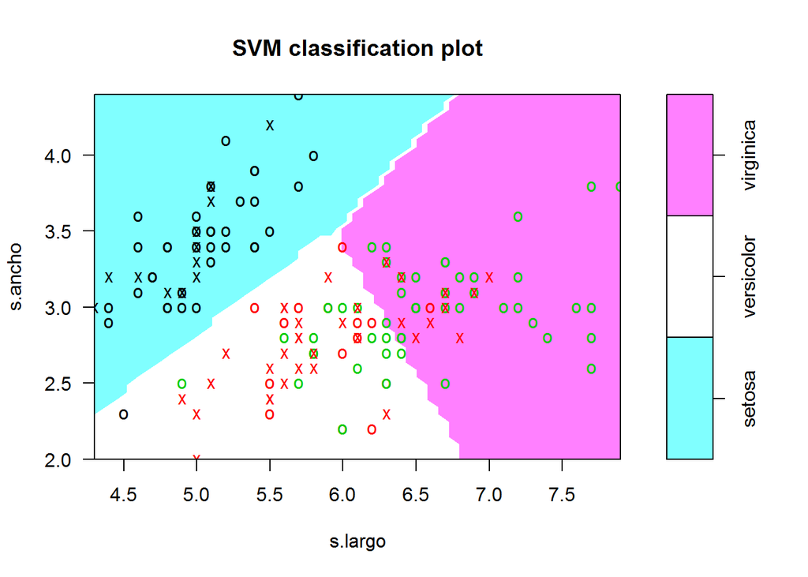

```r
plot(modelo, datos, s.ancho~s.largo, slice = list(s.ancho=1, s.largo=2))
```

# Example SVM with another data

load the data

```r
library(kknn)
datos <- read.csv("C:/Users/Usuario/Desktop/promidat/calibracion_y_seleccion/2/MuestraAprendizajeCredito2500.csv", sep = ";", dec = ".", header = TRUE)
ttesting <- read.table("C:/Users/Usuario/Desktop/promidat/calibracion_y_seleccion/2/MuestraTestCredito2500.csv", sep = ";", header = TRUE)

dim(datos)
```

```
## [1] 2500    6
```

```r
#tabla de aprendizake
taprendiz <- datos
```

Transform the Variables

```r
taprendiz$MontoCredito <- as.factor(taprendiz$MontoCredito)
taprendiz$IngresoNeto <- as.factor(taprendiz$IngresoNeto)
taprendiz$CoefCreditoAvaluo <- as.factor(taprendiz$CoefCreditoAvaluo)
taprendiz$MontoCuota <-  as.factor(taprendiz$MontoCuota)
taprendiz$GradoAcademico <- as.factor(taprendiz$GradoAcademico)
taprendiz$BuenPagador <- as.factor(taprendiz$BuenPagador)

#convertimos la de la tabla de testing
ttesting$MontoCredito <- as.factor(ttesting$MontoCredito)
ttesting$IngresoNeto <- as.factor(ttesting$IngresoNeto)
ttesting$CoefCreditoAvaluo <- as.factor(ttesting$CoefCreditoAvaluo)
ttesting$MontoCuota <- as.factor(ttesting$MontoCuota)
ttesting$GradoAcademico <- as.factor(ttesting$GradoAcademico)
ttesting$BuenPagador <- as.factor(ttesting$BuenPagador)
```

Build the model

```r
#implementamos el modelo
modelo <- svm(BuenPagador ~ ., data= taprendiz, kernel="linear")
modelo
```

```
##
## Call:
## svm(formula = BuenPagador ~ ., data = taprendiz, kernel = "linear")
##
##
## Parameters:
##    SVM-Type:  C-classification
##  SVM-Kernel:  linear
##        cost:  1
##       gamma:  0.05
##
## Number of Support Vectors:  565
```

The Prediction

```r
prediction<- predict(modelo, ttesting)
head(prediction)
```

```
##  1  2  3  4  5  6
## Si Si Si Si Si Si
## Levels: No Si
```

the confusion matrix

```r
matriz.conf<- table(ttesting[,6], prediction)
matriz.conf
```

```
##     prediction
##        No   Si
##   No  200  145
##   Si   29 2126
```

Hits Percentage

```r
aciertos<- sum(diag(matriz.conf))/sum(matriz.conf)
aciertos
```

```
## [1] 0.9304
```

The error:

```r
error<- 1 - aciertos
error
```

```
## [1] 0.0696
```

# Decision Tree

Load the Data

```r
library(rpart)
library(rpart.plot)
datos <- read.csv("C:/Users/Usuario/Desktop/promidat/calibracion_y_seleccion/2/iris.csv", sep = ";", dec = ".", header = TRUE)
head(datos)
```

```
##   s.largo s.ancho p.largo p.ancho   tipo
## 1     5.1     3.5     1.4     0.2 setosa
## 2     4.9     3.0     1.4     0.2 setosa
## 3     4.7     3.2     1.3     0.2 setosa
## 4     4.6     3.1     1.5     0.2 setosa
## 5     5.0     3.6     1.4     0.2 setosa
## 6     5.4     3.9     1.7     0.4 setosa
```

Build the Model

```r
modelo <- rpart(tipo~., data = datos)
modelo
```

```
## n= 150
##
## node), split, n, loss, yval, (yprob)
##       * denotes terminal node
##
## 1) root 150 100 setosa (0.33333333 0.33333333 0.33333333)
##   2) p.largo< 2.45 50   0 setosa (1.00000000 0.00000000 0.00000000) *
##   3) p.largo>=2.45 100  50 versicolor (0.00000000 0.50000000 0.50000000)
##     6) p.ancho< 1.75 54   5 versicolor (0.00000000 0.90740741 0.09259259) *
##     7) p.ancho>=1.75 46   1 virginica (0.00000000 0.02173913 0.97826087) *
```

Perform the Prediction

```r
prediction<- predict(modelo, datos, type = "class")
head(prediction)
```

```
##      1      2      3      4      5      6
## setosa setosa setosa setosa setosa setosa
## Levels: setosa versicolor virginica
```

the confusion matrix

```r
matriz.conf<- table(datos[,5], prediction)
matriz.conf
```

```
##             prediction
##              setosa versicolor virginica
##   setosa         50          0         0
##   versicolor      0         49         1
##   virginica       0          5        45
```

Hits

```r
aciertos<- sum(diag(matriz.conf))/sum(matriz.conf)
aciertos
```

```
## [1] 0.96
```

The error:

```r
error<- 1 - aciertos
error
```

```
## [1] 0.04
```

Ploting

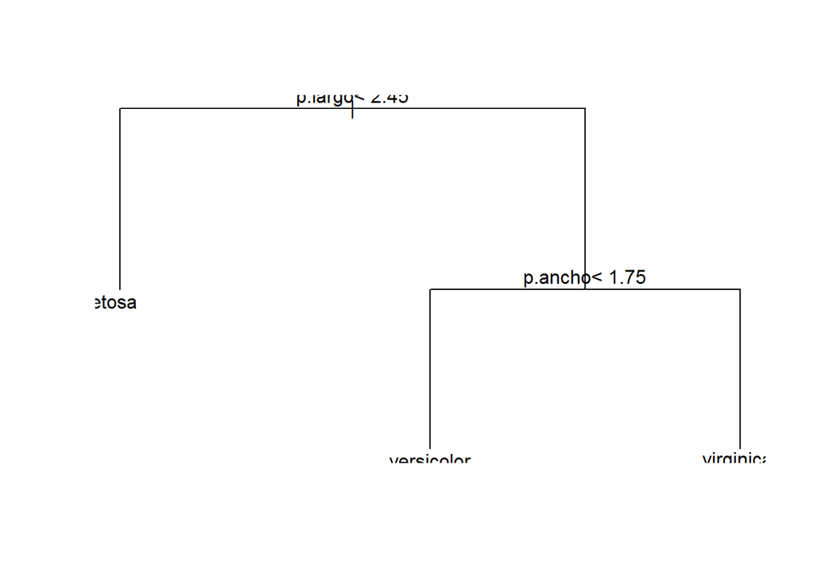

```r
plot(modelo)
text(modelo)
```

# Ploting with Rpart.plot

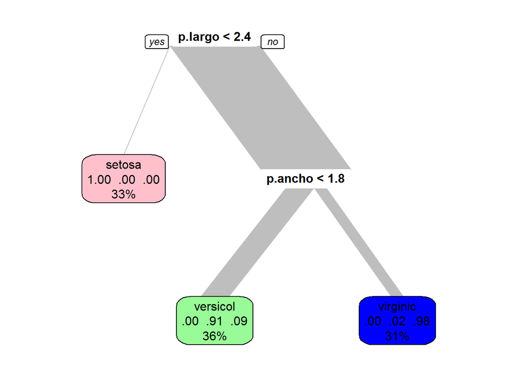

```r
prp(modelo, extra=104, branch.type = 2, box.col = c("pink", "palegreen", "blue")[modelo$frame$yval] )
```

# DT with another data

Load the Data

```r
library(kknn)
datos <- read.csv("C:/Users/Usuario/Desktop/promidat/calibracion_y_seleccion/2/MuestraAprendizajeCredito2500.csv", sep = ";", dec = ".", header = TRUE)
ttesting <- read.table("C:/Users/Usuario/Desktop/promidat/calibracion_y_seleccion/2/MuestraTestCredito2500.csv", sep = ";", header = TRUE)

dim(datos)
```

```
## [1] 2500    6
```

```r
#tabla de aprendizake
taprendiz <- datos
```

Transform the data

```r
taprendiz$MontoCredito <- as.factor(taprendiz$MontoCredito)
taprendiz$IngresoNeto <- as.factor(taprendiz$IngresoNeto)
taprendiz$CoefCreditoAvaluo <- as.factor(taprendiz$CoefCreditoAvaluo)
taprendiz$MontoCuota <-  as.factor(taprendiz$MontoCuota)
taprendiz$GradoAcademico <- as.factor(taprendiz$GradoAcademico)
taprendiz$BuenPagador <- as.factor(taprendiz$BuenPagador)

#convertimos la de la tabla de testing
ttesting$MontoCredito <- as.factor(ttesting$MontoCredito)
ttesting$IngresoNeto <- as.factor(ttesting$IngresoNeto)
ttesting$CoefCreditoAvaluo <- as.factor(ttesting$CoefCreditoAvaluo)
ttesting$MontoCuota <- as.factor(ttesting$MontoCuota)
ttesting$GradoAcademico <- as.factor(ttesting$GradoAcademico)
ttesting$BuenPagador <- as.factor(ttesting$BuenPagador)
```

The Model

```r
modelo <- rpart(BuenPagador~., data = taprendiz)
modelo
```

```
## n= 2500
##
## node), split, n, loss, yval, (yprob)
##       * denotes terminal node
##
##  1) root 2500 360 Si (0.14400000 0.85600000)
##    2) CoefCreditoAvaluo=4,6,8,9,11 934 249 Si (0.26659529 0.73340471)
##      4) GradoAcademico=1 171   9 No (0.94736842 0.05263158) *
##      5) GradoAcademico=2 763  87 Si (0.11402359 0.88597641)
##       10) MontoCredito=3,4 149  63 Si (0.42281879 0.57718121)
##         20) CoefCreditoAvaluo=8,9 32   5 No (0.84375000 0.15625000) *
##         21) CoefCreditoAvaluo=4,11 117  36 Si (0.30769231 0.69230769)
##           42) MontoCuota=1 16   2 No (0.87500000 0.12500000) *
##           43) MontoCuota=2,3,4 101  22 Si (0.21782178 0.78217822) *
##       11) MontoCredito=1,2 614  24 Si (0.03908795 0.96091205) *
##    3) CoefCreditoAvaluo=1,2,3,5,7,10,12 1566 111 Si (0.07088123 0.92911877)
##      6) MontoCuota=4 130  32 Si (0.24615385 0.75384615)
##       12) IngresoNeto=1 70  27 Si (0.38571429 0.61428571)
##         24) MontoCredito=2,3 42  18 No (0.57142857 0.42857143)
##           48) CoefCreditoAvaluo=12 28   5 No (0.82142857 0.17857143) *
##           49) CoefCreditoAvaluo=1,2,3,10 14   1 Si (0.07142857 0.92857143) *
##         25) MontoCredito=1,4 28   3 Si (0.10714286 0.89285714) *
##       13) IngresoNeto=2 60   5 Si (0.08333333 0.91666667) *
##      7) MontoCuota=1,2,3 1436  79 Si (0.05501393 0.94498607) *
```

Prediction;

```r
prediction<- predict(modelo, ttesting, type = "class")
head(prediction)
```

```
##  1  2  3  4  5  6
## Si Si Si Si Si Si
## Levels: No Si
```

the confusion matrix

```r
matriz.conf<- table(ttesting[,6], prediction)
matriz.conf
```

```
##     prediction
##        No   Si
##   No  221  124
##   Si   24 2131
```

Hits Percentage

```r
aciertos<- sum(diag(matriz.conf))/sum(matriz.conf)
aciertos
```

```
## [1] 0.9408
```

error:

```r
error<- 1 - aciertos
error
```

```
## [1] 0.0592
```

Ploting

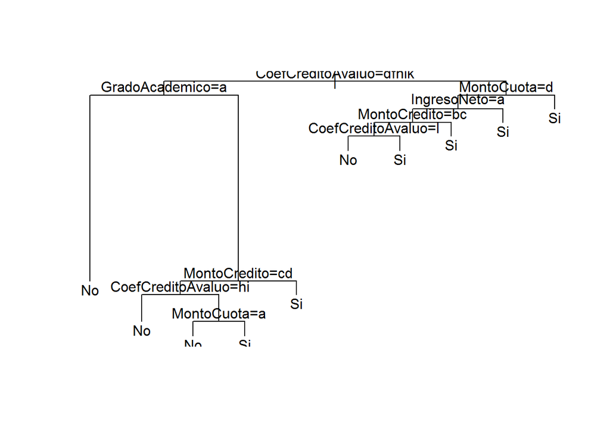

```r
plot(modelo)
text(modelo)
```

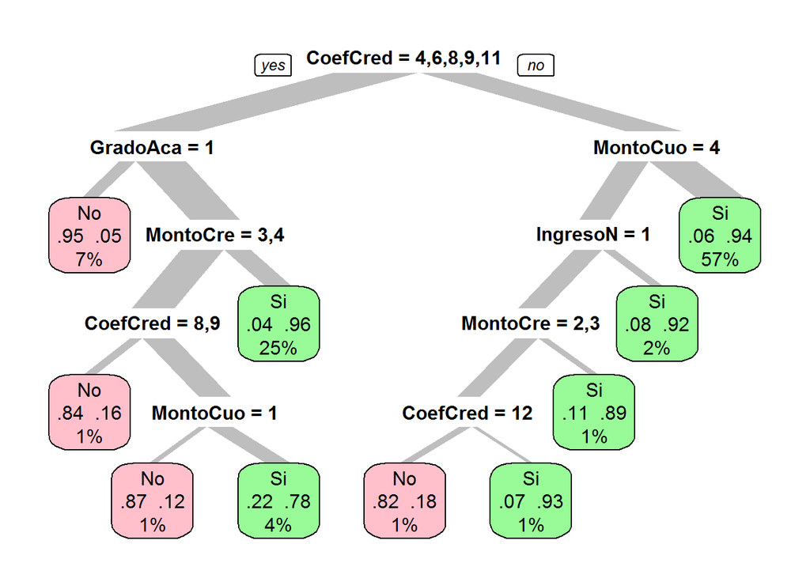

```r
prp(modelo, extra=104, branch.type = 2, box.col = c("pink", "palegreen", "blue")[modelo$frame$yval] )
```

# Random Forest

Load the Data

```r
library(randomForest)
datos <- read.csv("C:/Users/Usuario/Desktop/promidat/calibracion_y_seleccion/2/iris.csv", sep = ";", dec = ".", header = TRUE)
head(datos)
```

```
##   s.largo s.ancho p.largo p.ancho   tipo
## 1     5.1     3.5     1.4     0.2 setosa
## 2     4.9     3.0     1.4     0.2 setosa
## 3     4.7     3.2     1.3     0.2 setosa
## 4     4.6     3.1     1.5     0.2 setosa
## 5     5.0     3.6     1.4     0.2 setosa
## 6     5.4     3.9     1.7     0.4 setosa
```

```r
summary(datos)
```

```
##     s.largo         s.ancho         p.largo         p.ancho
##  Min.   :4.300   Min.   :2.000   Min.   :1.000   Min.   :0.100
##  1st Qu.:5.100   1st Qu.:2.800   1st Qu.:1.600   1st Qu.:0.300
##  Median :5.800   Median :3.000   Median :4.350   Median :1.300
##  Mean   :5.843   Mean   :3.054   Mean   :3.759   Mean   :1.199
##  3rd Qu.:6.400   3rd Qu.:3.300   3rd Qu.:5.100   3rd Qu.:1.800
##  Max.   :7.900   Max.   :4.400   Max.   :6.900   Max.   :2.500
##          tipo
##  setosa    :50
##  versicolor:50
##  virginica :50
##
##
##
```

making the Samples

```r
#Generamos muestra al azar
muestra<- sample(1:150, 50)
#tabla de testing
ttesting<-datos[muestra,]
#tabla de aprendizake
taprendiz <- datos[-muestra,]
```

Build the Model

```r
modelo <- randomForest(tipo~., data = taprendiz, importance= TRUE)
modelo
```

```
##
## Call:
##  randomForest(formula = tipo ~ ., data = taprendiz, importance = TRUE)
##                Type of random forest: classification
##                      Number of trees: 500
## No. of variables tried at each split: 2
##
##         OOB estimate of  error rate: 8%
## Confusion matrix:
##            setosa versicolor virginica class.error
## setosa         36          0         0  0.00000000
## versicolor      0         33         3  0.08333333
## virginica       0          5        23  0.17857143
```

Perform the Prediction

```r
prediction<- predict(modelo, ttesting, type = "class")
head(prediction)
```

```
##        105        108         31        109         88         32
##  virginica  virginica     setosa  virginica versicolor     setosa
## Levels: setosa versicolor virginica
```

the confusion matrix

```r
matriz.conf<- table(ttesting[,5], prediction)
matriz.conf
```

```
##             prediction
##              setosa versicolor virginica
##   setosa         14          0         0
##   versicolor      0         14         0
##   virginica       0          1        21
```

Hits Percentage

```r
aciertos<- sum(diag(matriz.conf))/sum(matriz.conf)
aciertos
```

```
## [1] 0.98
```

Error:

```r
error<- 1 - aciertos
error
```

```
## [1] 0.02
```

# Boosting Methods, i.e ADA

Load the Data

```r
library(ada)
datos <- read.csv("C:/Users/Usuario/Desktop/promidat/calibracion_y_seleccion/2/MuestraAprendizajeCredito2500.csv", sep = ";", dec = ".", header = TRUE)
ttesting <- read.table("C:/Users/Usuario/Desktop/promidat/calibracion_y_seleccion/2/MuestraTestCredito2500.csv", sep = ";", header = TRUE)

dim(datos)
```

```
## [1] 2500    6
```

```r
#tabla de aprendizake
taprendiz <- datos
```

Transform the Data

```r
taprendiz$MontoCredito <- as.factor(taprendiz$MontoCredito)
taprendiz$IngresoNeto <- as.factor(taprendiz$IngresoNeto)
taprendiz$CoefCreditoAvaluo <- as.factor(taprendiz$CoefCreditoAvaluo)
taprendiz$MontoCuota <-  as.factor(taprendiz$MontoCuota)
taprendiz$GradoAcademico <- as.factor(taprendiz$GradoAcademico)
taprendiz$BuenPagador <- as.factor(taprendiz$BuenPagador)

#convertimos la de la tabla de testing
ttesting$MontoCredito <- as.factor(ttesting$MontoCredito)
ttesting$IngresoNeto <- as.factor(ttesting$IngresoNeto)
ttesting$CoefCreditoAvaluo <- as.factor(ttesting$CoefCreditoAvaluo)
ttesting$MontoCuota <- as.factor(ttesting$MontoCuota)
ttesting$GradoAcademico <- as.factor(ttesting$GradoAcademico)
ttesting$BuenPagador <- as.factor(ttesting$BuenPagador)
```

Make the Model

```r
modelo <- ada(BuenPagador~., data = taprendiz, iter=100, nu=1, type= "discrete")
modelo
```

```
## Call:
## ada(BuenPagador ~ ., data = taprendiz, iter = 100, nu = 1, type = "discrete")
##
## Loss: exponential Method: discrete   Iteration: 100
##
## Final Confusion Matrix for Data:
##           Final Prediction
## True value   No   Si
##         No  268   92
##         Si   21 2119
##
## Train Error: 0.045
##
## Out-Of-Bag Error:  0.047  iteration= 97
##
## Additional Estimates of number of iterations:
##
## train.err1 train.kap1
##         74         74
```

Perform the Prediction

```r
prediction<- predict(modelo, ttesting)
head(prediction)
```

```
## [1] Si Si Si Si Si Si
## Levels: No Si
```

Create the confusion matrix

```r
matriz.conf<- table(ttesting[,6], prediction)
matriz.conf
```

```
##     prediction
##        No   Si
##   No  248   97
##   Si   31 2124
```

hits Percentage

```r
aciertos<- sum(diag(matriz.conf))/sum(matriz.conf)
aciertos
```

```
## [1] 0.9488
```

Error:

```r
error<- 1 - aciertos
error
```

```
## [1] 0.0512
```

Ploting the Results

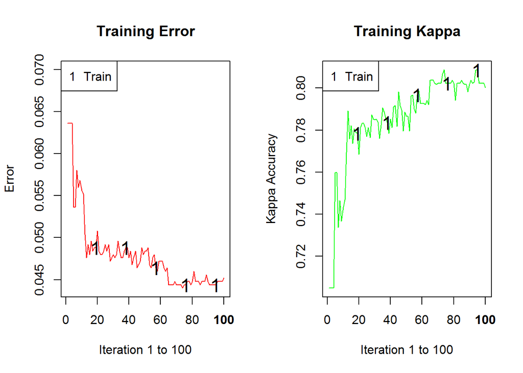

```r
plot(modelo, TRUE,TRUE)
```

## Best Variables

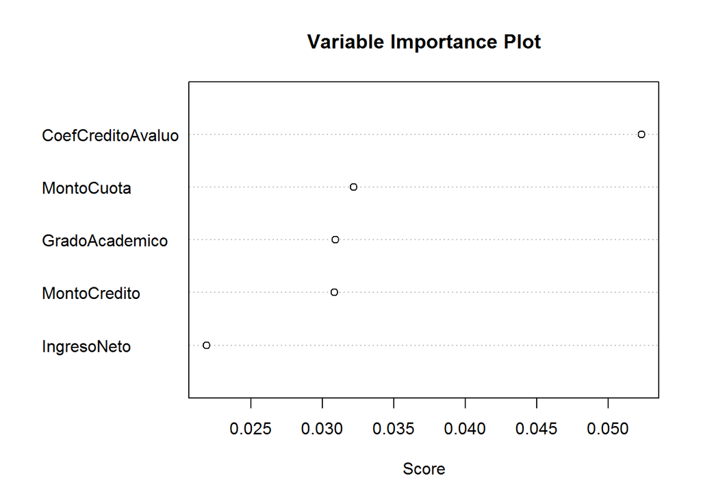

```r
varplot(modelo)
```

# Neural Networks examples

Load the data

```r
library(nnet)
datos <- read.csv("C:/Users/Usuario/Desktop/promidat/calibracion_y_seleccion/2/iris.csv", sep = ";", dec = ".", header = TRUE)
head(datos)
```

```
##   s.largo s.ancho p.largo p.ancho   tipo
## 1     5.1     3.5     1.4     0.2 setosa
## 2     4.9     3.0     1.4     0.2 setosa
## 3     4.7     3.2     1.3     0.2 setosa
## 4     4.6     3.1     1.5     0.2 setosa
## 5     5.0     3.6     1.4     0.2 setosa
## 6     5.4     3.9     1.7     0.4 setosa
```

```r
summary(datos)
```

```
##     s.largo         s.ancho         p.largo         p.ancho
##  Min.   :4.300   Min.   :2.000   Min.   :1.000   Min.   :0.100
##  1st Qu.:5.100   1st Qu.:2.800   1st Qu.:1.600   1st Qu.:0.300
##  Median :5.800   Median :3.000   Median :4.350   Median :1.300
##  Mean   :5.843   Mean   :3.054   Mean   :3.759   Mean   :1.199
##  3rd Qu.:6.400   3rd Qu.:3.300   3rd Qu.:5.100   3rd Qu.:1.800
##  Max.   :7.900   Max.   :4.400   Max.   :6.900   Max.   :2.500
##          tipo
##  setosa    :50
##  versicolor:50
##  virginica :50
##
##
##
```

Made the samples

```r
#Generamos muestra al azar
muestra<- sample(1:150, 50)
#tabla de testing
ttesting<-datos[muestra,]
#tabla de aprendizake
taprendiz <- datos[-muestra,]
```

Create the model

```r
modelo <- nnet(tipo~., data = taprendiz, size=4, rang= 0.1, decay=5e-4, maxit=200, trace= FALSE)
modelo
```

```
## a 4-4-3 network with 35 weights
## inputs: s.largo s.ancho p.largo p.ancho
## output(s): tipo
## options were - softmax modelling  decay=5e-04
```

The Prediction

```r
prediction<- predict(modelo, ttesting[,-5], type = "class")
head(prediction)
```

```
## [1] "versicolor" "versicolor" "setosa"     "setosa"     "setosa"
## [6] "setosa"
```

Create the confusion matrix

```r
matriz.conf<- table(ttesting[,5], prediction)
matriz.conf
```

```
##             prediction
##              setosa versicolor virginica
##   setosa         18          0         0
##   versicolor      0         15         0
##   virginica       0          2        15
```

Hits Percentage

```r
aciertos<- sum(diag(matriz.conf))/sum(matriz.conf)
aciertos
```

```
## [1] 0.96
```

The error:

```r
error<- 1 - aciertos
error
```

```
## [1] 0.04
```

# Save the model on the drive for later :)

Load the Datas

```r
library(nnet)
datos <- read.csv("C:/Users/Usuario/Desktop/promidat/calibracion_y_seleccion/2/iris.csv", sep = ";", dec = ".", header = TRUE)
head(datos)
```

```
##   s.largo s.ancho p.largo p.ancho   tipo
## 1     5.1     3.5     1.4     0.2 setosa
## 2     4.9     3.0     1.4     0.2 setosa
## 3     4.7     3.2     1.3     0.2 setosa
## 4     4.6     3.1     1.5     0.2 setosa
## 5     5.0     3.6     1.4     0.2 setosa
## 6     5.4     3.9     1.7     0.4 setosa
```

```r
summary(datos)
```

```
##     s.largo         s.ancho         p.largo         p.ancho
##  Min.   :4.300   Min.   :2.000   Min.   :1.000   Min.   :0.100
##  1st Qu.:5.100   1st Qu.:2.800   1st Qu.:1.600   1st Qu.:0.300
##  Median :5.800   Median :3.000   Median :4.350   Median :1.300
##  Mean   :5.843   Mean   :3.054   Mean   :3.759   Mean   :1.199
##  3rd Qu.:6.400   3rd Qu.:3.300   3rd Qu.:5.100   3rd Qu.:1.800
##  Max.   :7.900   Max.   :4.400   Max.   :6.900   Max.   :2.500
##          tipo
##  setosa    :50
##  versicolor:50
##  virginica :50
##
##
##
```

the samples are generated

```r
#Generamos muestra al azar
muestra<- sample(1:150, 50)
#tabla de testing
ttesting<-datos[muestra,]
#tabla de aprendizake
taprendiz <- datos[-muestra,]
```

Build the model

```r
modelo <- nnet(tipo~., data = taprendiz, size=4, rang= 0.1, decay=5e-4, maxit=20, trace= FALSE)
modelo
```

```
## a 4-4-3 network with 35 weights
## inputs: s.largo s.ancho p.largo p.ancho
## output(s): tipo
## options were - softmax modelling  decay=5e-04
```

# save

```r
save(modelo, file = "modelos_redes_iris.rda")
```

# We can retrieve our model with load

```r
load("modelos_redes_iris.rda")
```

The Prediction:

```r
prediction<- predict(modelo, ttesting[,-5], type = "class")
head(prediction)
```

```
## [1] "setosa"    "virginica" "virginica" "setosa"    "virginica" "virginica"
```

the confusion matrix

```r
matriz.conf<- table(ttesting[,5], prediction)
matriz.conf
```

```
##             prediction
##              setosa versicolor virginica
##   setosa         17          0         0
##   versicolor      0         19         2
##   virginica       0          0        12
```

hits Percentages

```r
aciertos<- sum(diag(matriz.conf))/sum(matriz.conf)
aciertos
```

```
## [1] 0.96
```

Error:

```r
error<- 1 - aciertos
error
```

```
## [1] 0.04
```